# Casual vs Member: Ride Duration Insights

## When Do We Ride? Time-of-Day Patterns Across Rider Groups

### “Casual riders linger longer, especially after dark — while members keep it short and steady.

This chart demonstrates that members keep it short and steady whilst casual riders linger longer especially after dark. To convert more casual riders, I suggest we offer them flexible membership plans especially for those who are simply visiting the city for a short period of time. We could use the following tag line to grab their attention, “Grab your 10% evening membership discount now.”

```r
#Time of Day: average ride duration

station_data_clean <- station_data_clean %>%
  mutate(
    hour = lubridate::hour(started_at),
    time_of_day = case_when(
      hour >= 5 & hour < 12 ~ "Morning",
      hour >= 12 & hour < 17 ~ "Afternoon",
      hour >= 17 & hour < 21 ~ "Evening",
      TRUE ~ "Night"
    ),
    time_of_day = factor(time_of_day, levels = c("Morning", "Afternoon", "Evening", "Night"))
  )

duration_by_time <- station_data_clean %>%
  group_by(time_of_day, rider_group) %>%
  summarise(avg_duration = mean(ride_length_mins_2, na.rm = TRUE)) %>%
  arrange(match(time_of_day, c("Early Morning", "Mid Morning", "Afternoon", "Evening", "Night")))
```

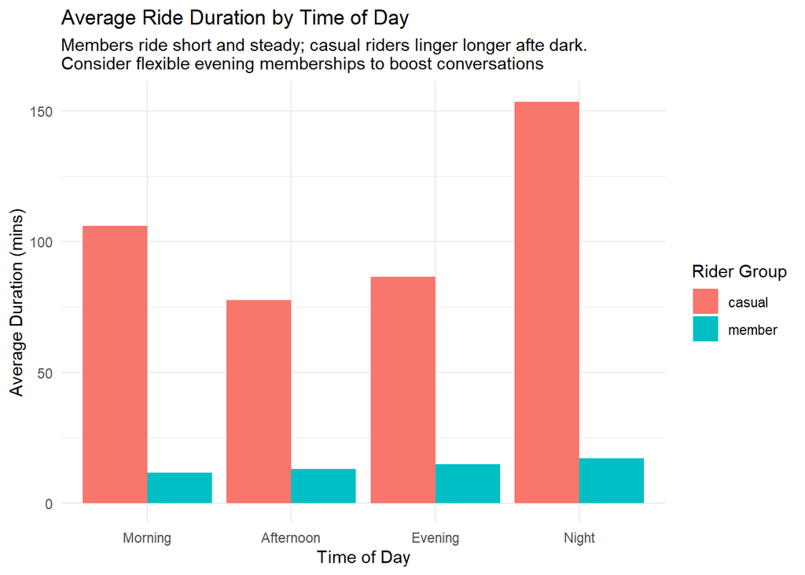

```r
station_data_clean <- station_data_clean %>%
  mutate(time_of_day = factor(time_of_day,
                              levels = c("Early Morning", "Mid Morning", "Afternoon", "Evening", "Late Night")))

ggplot(duration_by_time, aes(x = time_of_day, y = avg_duration, fill = rider_group)) +
  geom_col(position = "dodge") +
  labs(title = "Average Ride Duration by Time of Day",
       subtitle = "Members ride short and steady; casual riders linger longer afte dark.\nConsider flexible evening memberships to boost conversations",
       x = "Time of Day",
       y = "Average Duration (mins)",
       fill = "Rider Group") +
  theme_minimal()
```

## Top paired stations

The following is a ggplot graph that shows the top paired stations. Why this is important? Because we can use this data to advertise future membership plans in ad boards around those 10 top stations. The data lacks consistent demographic data which does not enable us to dip deeper into best ad practices. This however does not stop us from focusing around these top ten stations. We understand that folks ride longer after dark, this gices us strong indication that rider enjoy night riding along the canal.

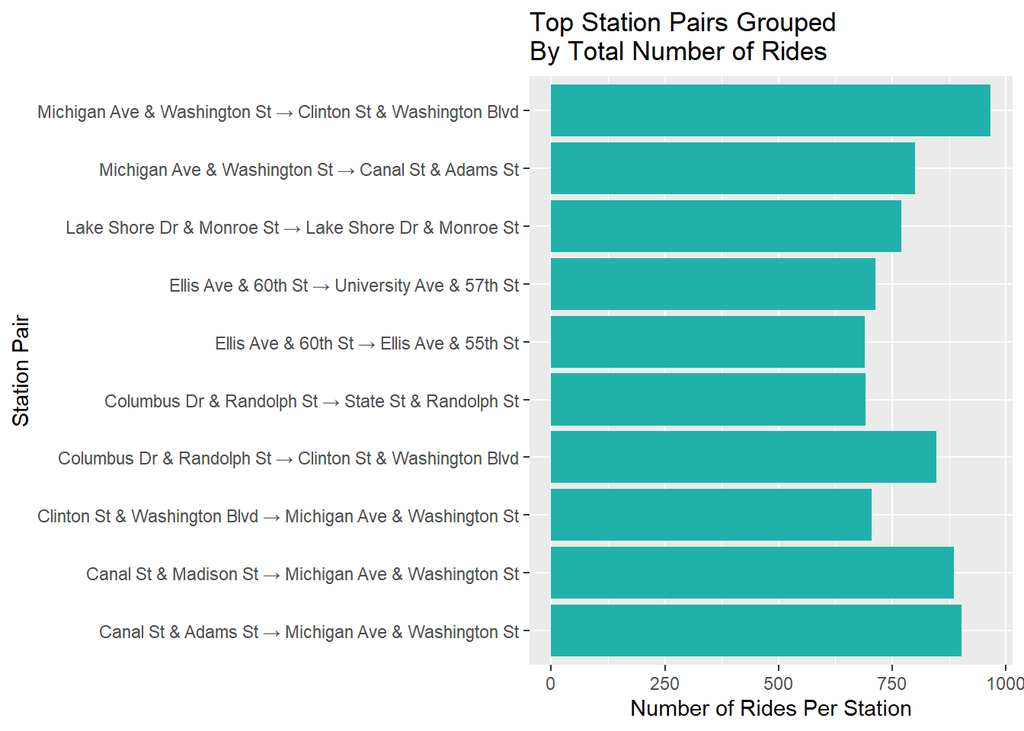

```r
# top paired stations.

top_pairs <- station_data_clean %>%
     count(pair, sort = TRUE) %>%
     slice_head(n = 10)


ggplot(top_pairs, aes(x = pair, y = n)) + geom_col(fill = "#20B2AA") +
    labs(
        title = "Top Station Pairs Grouped \nBy Total Number of Rides",
        x = "Station Pair",
        y = "Number of Rides Per Station"
    ) + coord_flip()
```